# Human Resource Analytics

## Why are our best and most experienced employees leaving prematurely?

```
                                                                                    By: Kanza Batool Haider
                                                                                    Data Science, Master Student
                                                                                    Istanbul Sehir University
                                                                                    COURSE: Machine Learning
                                                                                    INSTRUCTOR: Prof.Mehmet Serkan Apydin
                                                                                    FINAL PROJECT REPORT
                                                                                    DATE: 13/2/2018
```

### Characteristics/abnormalities in the dataset

The dataset was processed to check for any missing values in the data however, the data was clean with no missing values so no efforts were required further.

# Analysis (Data Exploration)

```python
import os
import tarfile
import pandas as pd

def load_hr_analytics_data():
   return pd.read_csv("HR_comma_sep.csv")

HR = load_hr_analytics_data()
```

```python
#Just looking at the raw data we have (initial few instances from the data)

HR.head()
```

|  | satisfaction_level | last_evaluation | number_project | average_montly_hours | time_spend_company | Work_accident | left | promotion_last_5years | sales | salary |
| --- | --- | --- | --- | --- | --- | --- | --- | --- | --- | --- |
| 0 | 0.38 | 0.53 | 2 | 157 | 3 | 0 | 1 | 0 | sales | low |
| 1 | 0.80 | 0.86 | 5 | 262 | 6 | 0 | 1 | 0 | sales | medium |
| 2 | 0.11 | 0.88 | 7 | 272 | 4 | 0 | 1 | 0 | sales | medium |
| 3 | 0.72 | 0.87 | 5 | 223 | 5 | 0 | 1 | 0 | sales | low |
| 4 | 0.37 | 0.52 | 2 | 159 | 3 | 0 | 1 | 0 | sales | low |

```python
#Looking numerical counts of employees working in each department of the company

HR["sales"].value_counts()
```

```
sales          4140
technical      2720
support        2229
IT             1227
product_mng     902
marketing       858
RandD           787
accounting      767
hr              739
management      630
Name: sales, dtype: int64
```

```python
#Looking at the number of employees having low, medium and high salaries

HR["salary"].value_counts()
```

```
low       7316
medium    6446
high      1237
Name: salary, dtype: int64
```

#### Visual images of different features of the employees data

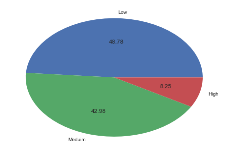

```python
#Displaying the salaries of the employees as 'Low', 'Medium' and 'High' as percentages in the pie graph

count= HR["salary"].value_counts()
import matplotlib.pyplot as plt
plt.pie(count, labels = ['Low', 'Meduim','High'], autopct='%.2f')
```

```python
#Looking at the number of people who are still working and the employees who left
# 0 represents employee is still staying in the company
# 1 represents employee has left the company

counts= HR["left"].value_counts()
print(counts)
```

```
0    11428
1     3571
Name: left, dtype: int64
```

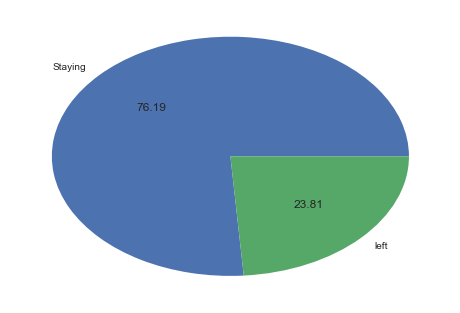

```python
#Displaying the percentages of employees staying in the company and those who left

import matplotlib.pyplot as plt
plt.pie(counts, labels = ['Staying', 'left'], autopct='%.2f')
```

76% employees staying in the company  
23% employees left the company

```python
#Statistical measures of central tendency such as the mean, standard deviation and percentiles computed under the table below
HR.describe()
```

[output not shown]

Analysis from central tendency:

We can see that our attrition rate is equal to 24%, the satisfaction level is around 62% and the performance average is around 71%. We see that on average people work on 3 to 4 projects a year and about 200 hours per months.

[figure not shown]

```python
#Having a histogram plot of each category feature that gives a better visualization for the ranges

%matplotlib inline
import matplotlib.pyplot as plt
HR.hist(bins=50, figsize=(20,15))
plt.show()
```

```python
#Looking out for any NAN values in the data

HR.loc[:, HR.isnull().any()]
```

[output not shown]

14999 rows × 0 columns

The only index column output indicates that the data DO NOT consist of any NAN values which should have been replaced with mean values.

#### Attribute study of employees ‘leaving’ Vs ‘staying’ in the company

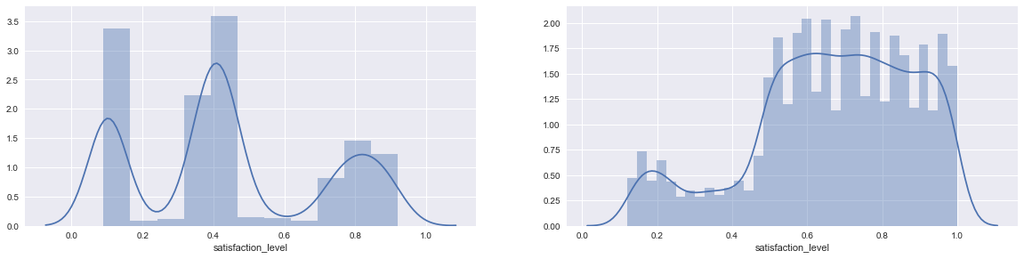

```python
# Comparing the satisfaction levels

import seaborn as sns
import matplotlib.pyplot as plt
import warnings
warnings.filterwarnings('ignore')

# Getting data of employees that left the company and those who stay

left = HR[HR['left']==1]
stay =HR[HR['left']==0]

# Adding and giving dimension to two sub plots
fig = plt.figure(figsize=(20,10))
fg1 = fig.add_subplot(221)
fg2 = fig.add_subplot(222)


sns.distplot(left['satisfaction_level'],ax = fg1);
sns.distplot(stay['satisfaction_level'],ax = fg2);
```

The first plot shows the satisfaction level of employees who left the job The second plot shows the satisfaction level of employees staying in the job

Analysis: Clearly, more ratio of people leaving the job shows lower levels of satisfaction level. Mostly below 0.5 Employees staying in the company shows better satisfaction level, majorly greater ratio of people shows above 0.5 satisfaction level

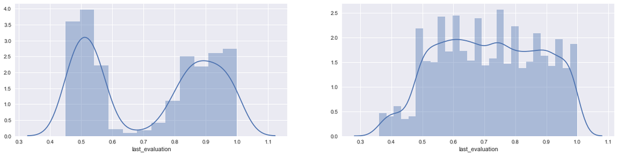

```python
# Comparing the 'last evaluation' levels

fig = plt.figure(figsize=(20,10))
fg1 = fig.add_subplot(221)
fg2 = fig.add_subplot(222)

sns.distplot(left['last_evaluation'], kde=True,ax=fg1);
sns.distplot(stay['last_evaluation'], kde=True,ax=fg2);
```

The two plots shows that the employees who left (first plot) their evaluation was more of in the extremes of either 0.5 or 0.9 whereas the people staying in the company(second plot) indicates that most of the employees last evaluation was graded above 0.5

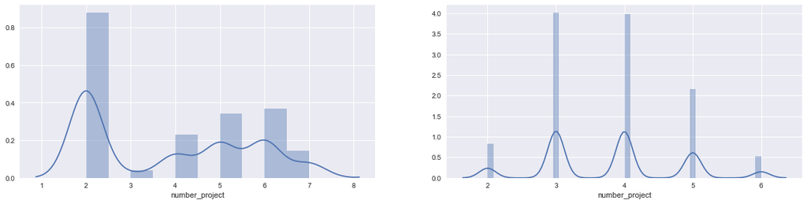

```python
# Comparing the 'number of projects'

# Adding and giving dimension to two sub plots
fig = plt.figure(figsize=(20,10))
fg1 = fig.add_subplot(221)
fg2 = fig.add_subplot(222)

sns.distplot(left['number_project'], kde=True,ax=fg1);

sns.distplot(stay['number_project'], kde=True,ax=fg2);
```

Almost half of the number of employees who 'left' did only 2 projects during their time. Whereas, employees staying have varying number of projects done indicatiing more as 3 and 4 projects.

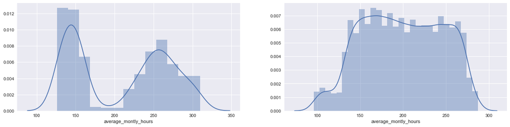

```python
# Comparing the 'Average monthly hours'


fig = plt.figure(figsize=(20,10))
fg1 = fig.add_subplot(221)
fg2 = fig.add_subplot(222)

sns.distplot(left['average_montly_hours'], kde=True,ax=fg1);

sns.distplot(stay['average_montly_hours'], kde=True,ax=fg2);
```

Employees who left seems to have devoted their work in either of the two extremes of 150 hours or 250 hours per month. Whereas, employees who stayed worked equally in the range between 140 to 270 hours (approximately).

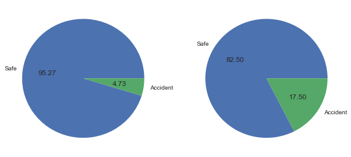

```python
#Comparing work accidents

fig = plt.figure(figsize=(10,10))
fg1 = fig.add_subplot(221)
fg2 = fig.add_subplot(222)

# value counts for work accident
leftaccidentcounts = left['Work_accident'].value_counts()
stayaccidentcounts = stay['Work_accident'].value_counts()


# plot each pie chart in a separate subplot
fg1.pie(leftaccidentcounts,labels=['Safe', 'Accident'], autopct='%.2f');
fg2.pie(stayaccidentcounts,labels=['Safe', 'Accident'], autopct='%.2f');
```

Apparently, more people who left the company were less affected by accidents compared to people who are staying in the company

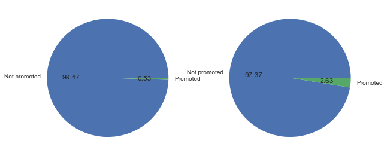

```python
#Comparing promotion's in last five years

fig = plt.figure(figsize=(10,10))
ax1 = fig.add_subplot(221)
ax2 = fig.add_subplot(222)

leftpromotioncounts = left['promotion_last_5years'].value_counts()
staypromotioncounts = stay['promotion_last_5years'].value_counts()


ax1.pie(leftpromotioncounts,labels=['Not promoted','Promoted'], autopct='%.2f');
ax2.pie(staypromotioncounts,labels=['Not promoted','Promoted'], autopct='%.2f');
```

Apparently, people staying in the company(fig2) seems to have been promoted little more than those who left (fig1)

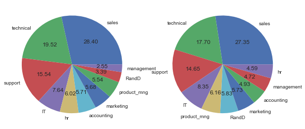

```python
#Pie chart to compare people belonging to different department


fig = plt.figure(figsize=(10,10))
fg1 = fig.add_subplot(221)
fg2 = fig.add_subplot(222)

leftdepartmentcounts = left['sales'].value_counts()
staydepartmentcounts = stay['sales'].value_counts()


fg1.pie(leftdepartmentcounts,labels=leftdepartmentcounts.index, autopct='%.2f');
fg2.pie(staydepartmentcounts,labels=staydepartmentcounts.index, autopct='%.2f');
```

Nothing much distinguishable can be related here

#### Correlation among features of data

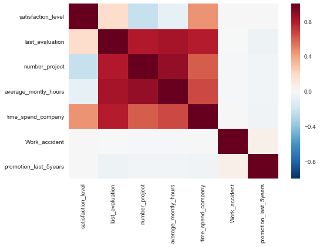

```python
corr = left.drop('left',axis=1).corr()
sns.heatmap(corr)
```

Correlation analysis shows that 'number of projects' are heavily dependent on the 'average number of hours' spent by the employee Also, 'average monthly hours' is also heavily correlated with 'last evaluation points' of the empoyee.

# Employees from which department leave the most

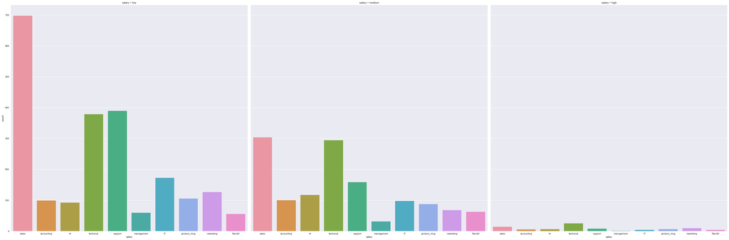

```python
# Plotting graph that shows count of people leaving from every department
# The graph has been splitted based on the salaries of employees in each department as 'low', 'medium' and 'high'

sns.factorplot(x="sales",data=left,col="salary",kind='count',aspect=1,size=14)
```

When the salary is low, large proportion of employees tend to leave the job from sales department.

```python
#Mapping salary to 0,1,2
HR.salary = HR.salary.map({'low':0,'medium':1,'high':2})
```

```python
#Generate X and y
X = HR.drop(['left','sales'],1)
y = HR['left']
```

```python
# Scaling features
from sklearn.preprocessing import StandardScaler
scaled_features = StandardScaler().fit_transform(X.values)
```

```python
# Replacing the column heads with the original column names
new_df3 = pd.DataFrame(scaled_features, columns = X.columns)
```

```python
# Print scaled X dataframe
new_df3
```

|  | satisfaction_level | last_evaluation | number_project | average_montly_hours | time_spend_company | Work_accident | promotion_last_5years | salary |
| --- | --- | --- | --- | --- | --- | --- | --- | --- |
| 0 | -0.936495 | -1.087275 | -1.462863 | -0.882040 | -0.341235 | -0.411165 | -0.147412 | -0.933368 |
| 1 | 0.752814 | 0.840707 | 0.971113 | 1.220423 | 1.713436 | -0.411165 | -0.147412 | 0.636092 |
| 2 | -2.022479 | 0.957554 | 2.593763 | 1.420657 | 0.343655 | -0.411165 | -0.147412 | 0.636092 |
| 3 | 0.431041 | 0.899131 | 0.971113 | 0.439508 | 1.028546 | -0.411165 | -0.147412 | -0.933368 |
| 4 | -0.976716 | -1.145699 | -1.462863 | -0.841993 | -0.341235 | -0.411165 | -0.147412 | -0.933368 |
| 5 | -0.815830 | -1.262546 | -1.462863 | -0.962134 | -0.341235 | -0.411165 | -0.147412 | -0.933368 |
| 6 | -2.062701 | 0.314894 | 1.782438 | 0.920071 | 0.343655 | -0.411165 | -0.147412 | -0.933368 |
| 7 | 1.235474 | 0.782283 | 0.971113 | 1.160352 | 1.028546 | -0.411165 | -0.147412 | -0.933368 |
| 8 | 1.114809 | 1.658639 | 0.971113 | 0.459532 | 1.028546 | -0.411165 | -0.147412 | -0.933368 |
| 9 | -0.775608 | -1.087275 | -1.462863 | -1.182392 | -0.341235 | -0.411165 | -0.147412 | -0.933368 |
| 10 | -0.654943 | -1.028852 | -1.462863 | -1.322556 | -0.341235 | -0.411165 | -0.147412 | -0.933368 |
| 11 | -2.022479 | 0.548588 | 1.782438 | 2.081431 | 0.343655 | -0.411165 | -0.147412 | -0.933368 |
| 12 | 0.913701 | 1.191249 | 0.159788 | 0.659766 | 1.028546 | -0.411165 | -0.147412 | -0.933368 |
| 13 | -0.815830 | -0.970428 | -1.462863 | -1.062251 | -0.341235 | -0.411165 | -0.147412 | -0.933368 |
| 14 | -1.016938 | -0.912004 | -1.462863 | -1.282509 | -0.341235 | -0.411165 | -0.147412 | -0.933368 |
| 15 | -0.936495 | -1.028852 | -1.462863 | -1.162368 | -0.341235 | -0.411165 | -0.147412 | -0.933368 |
| 16 | -0.654943 | -1.437818 | -1.462863 | -0.821970 | -0.341235 | -0.411165 | -0.147412 | -0.933368 |
| 17 | 0.672371 | 1.600215 | 0.159788 | 1.080259 | 1.713436 | -0.411165 | -0.147412 | -0.933368 |
| 18 | -0.654943 | -1.204123 | -1.462863 | -0.821970 | -0.341235 | 2.432112 | 6.783716 | -0.933368 |
| 19 | 0.591928 | 1.015978 | 0.971113 | 1.220423 | 1.028546 | -0.411165 | -0.147412 | -0.933368 |
| 20 | -2.022479 | 0.665436 | 1.782438 | 1.620892 | 0.343655 | -0.411165 | -0.147412 | -0.933368 |
| 21 | -0.936495 | -0.970428 | -1.462863 | -1.082274 | -0.341235 | -0.411165 | -0.147412 | -0.933368 |
| 22 | -2.102922 | 1.366520 | 1.782438 | 2.061408 | 0.343655 | -0.411165 | -0.147412 | -0.933368 |
| 23 | -0.614722 | -0.853580 | -1.462863 | -1.242462 | -0.341235 | -0.411165 | -0.147412 | -0.933368 |
| 24 | -0.856051 | -1.087275 | -1.462863 | -0.862016 | -0.341235 | -0.411165 | -0.147412 | -0.933368 |
| 25 | 1.114809 | 1.191249 | 0.971113 | 0.819954 | 1.028546 | -0.411165 | -0.147412 | -0.933368 |
| 26 | 0.833258 | 0.899131 | 0.159788 | 0.759883 | 1.028546 | -0.411165 | -0.147412 | -0.933368 |
| 27 | -0.856051 | -1.320970 | -1.462863 | -1.322556 | -0.341235 | -0.411165 | -0.147412 | -0.933368 |
| 28 | -0.815830 | -1.496241 | -1.462863 | -1.462720 | -0.341235 | -0.411165 | -0.147412 | -0.933368 |
| 29 | -0.936495 | -1.262546 | -1.462863 | -1.382626 | -0.341235 | -0.411165 | -0.147412 | -0.933368 |
| ... | ... | ... | ... | ... | ... | ... | ... | ... |
| 14969 | -0.735386 | -1.496241 | -1.462863 | -0.882040 | -0.341235 | -0.411165 | -0.147412 | 0.636092 |
| 14970 | 0.672371 | 1.249673 | 0.159788 | 0.479555 | 1.028546 | -0.411165 | -0.147412 | 0.636092 |
| 14971 | -0.896273 | -1.554665 | -1.462863 | -1.222439 | -0.341235 | -0.411165 | -0.147412 | 0.636092 |
| 14972 | -2.022479 | 1.483368 | 1.782438 | 2.181549 | 0.343655 | -0.411165 | -0.147412 | 0.636092 |
| 14973 | -1.016938 | -1.145699 | -1.462863 | -1.162368 | -0.341235 | -0.411165 | -0.147412 | 0.636092 |
| 14974 | -1.016938 | -1.028852 | -1.462863 | -0.962134 | -0.341235 | -0.411165 | -0.147412 | 0.636092 |
| 14975 | -2.062701 | 0.431741 | 2.593763 | 2.181549 | 0.343655 | -0.411165 | -0.147412 | 0.636092 |
| 14976 | -0.856051 | -1.437818 | -1.462863 | -1.302532 | -0.341235 | -0.411165 | -0.147412 | 0.636092 |
| 14977 | 0.793036 | 0.782283 | 0.159788 | 1.000165 | 1.713436 | -0.411165 | -0.147412 | 0.636092 |
| 14978 | -0.856051 | -1.437818 | -1.462863 | -1.142345 | -0.341235 | -0.411165 | -0.147412 | 0.636092 |
| 14979 | -2.102922 | 1.249673 | 1.782438 | 1.901220 | 0.343655 | -0.411165 | -0.147412 | 0.636092 |
| 14980 | 0.591928 | 1.015978 | 0.971113 | 0.739860 | 1.028546 | -0.411165 | -0.147412 | 2.205553 |
| 14981 | 0.471263 | 1.249673 | 0.971113 | -0.781923 | 0.343655 | -0.411165 | -0.147412 | -0.933368 |
| 14982 | -0.936495 | -1.320970 | -1.462863 | -1.282509 | -0.341235 | -0.411165 | -0.147412 | 0.636092 |
| 14983 | 0.431041 | 0.723860 | 0.971113 | 1.120305 | 1.028546 | -0.411165 | -0.147412 | 0.636092 |
| 14984 | -0.856051 | -0.912004 | -1.462863 | -1.062251 | -0.341235 | -0.411165 | -0.147412 | 0.636092 |
| 14985 | 1.195252 | 1.600215 | 0.971113 | 1.060235 | 1.028546 | -0.411165 | -0.147412 | 0.636092 |
| 14986 | 0.953923 | 0.782283 | 0.159788 | 0.920071 | 1.713436 | -0.411165 | -0.147412 | -0.933368 |
| 14987 | 1.155031 | -0.094072 | 0.971113 | 0.099109 | 0.343655 | -0.411165 | -0.147412 | -0.933368 |
| 14988 | -0.614722 | -0.970428 | -1.462863 | -1.122321 | -0.341235 | -0.411165 | -0.147412 | -0.933368 |
| 14989 | -0.735386 | -0.853580 | -1.462863 | -0.841993 | -0.341235 | 2.432112 | -0.147412 | -0.933368 |
| 14990 | 1.114809 | 0.957554 | 0.971113 | 0.539625 | 1.028546 | 2.432112 | -0.147412 | -0.933368 |
| 14991 | -2.102922 | 0.548588 | 1.782438 | 1.120305 | 0.343655 | -0.411165 | -0.147412 | -0.933368 |
| 14992 | -0.856051 | -1.379394 | -1.462863 | -0.922087 | -0.341235 | -0.411165 | -0.147412 | -0.933368 |
| 14993 | 0.591928 | 0.665436 | 1.782438 | 1.841150 | 1.713436 | -0.411165 | -0.147412 | -0.933368 |
| 14994 | -0.856051 | -0.853580 | -1.462863 | -1.002181 | -0.341235 | -0.411165 | -0.147412 | -0.933368 |
| 14995 | -0.976716 | -1.379394 | -1.462863 | -0.821970 | -0.341235 | -0.411165 | -0.147412 | -0.933368 |
| 14996 | -0.976716 | -1.087275 | -1.462863 | -1.162368 | -0.341235 | -0.411165 | -0.147412 | -0.933368 |
| 14997 | -2.022479 | 1.424944 | 1.782438 | 1.580845 | 0.343655 | -0.411165 | -0.147412 | -0.933368 |
| 14998 | -0.976716 | -1.145699 | -1.462863 | -0.862016 | -0.341235 | -0.411165 | -0.147412 | -0.933368 |

14999 rows × 8 columns

#### Classifier Support Vector Machine

```python
import numpy as np
from sklearn import svm
```

```python
#splitting the train and test sets
from sklearn.model_selection import train_test_split
X_train, X_test, y_train,y_test= train_test_split(new_df3,y,test_size=0.2)
```

```python
#Trainng and fitting data into the model classifier
clf = svm.SVC()
clf.fit(X_train,y_train)
```

```
SVC(C=1.0, cache_size=200, class_weight=None, coef0=0.0,
  decision_function_shape=None, degree=3, gamma='auto', kernel='rbf',
  max_iter=-1, probability=False, random_state=None, shrinking=True,
  tol=0.001, verbose=False)
```

```python
#Accuracy of sVM classifier
accuracy = clf.score(X_test,y_test)
print(accuracy *100,'%')
```

```
96.6 %
```

```python
#Displaying some of the predicted values
pd.DataFrame(clf.predict(X_test),y_test,columns=['ytest']).head()
```

| left | ytest |
| --- | --- |
| 1 | 1 |
| 1 | 1 |
| 0 | 0 |
| 0 | 0 |
| 0 | 0 |

## Ranking of most important features for which the employees leave

```
Feature ranking:
1.   satisfaction_level (0.255157)
2.   last_evaluation (0.226557)
3.   number_project (0.178257)
4.   average_montly_hours (0.155093)
5.   time_spend_company (0.142663)
6.   Work_accident (0.020138)
7.   promotion_last_5years (0.018898)
8.   salary (0.003237)
```

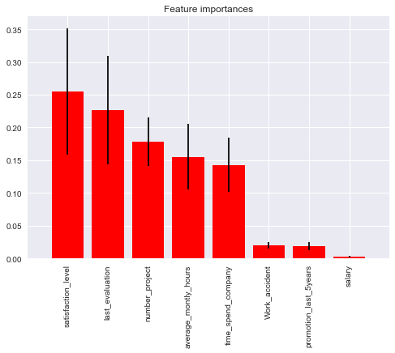

```python
import numpy as np
import matplotlib.pyplot as plt

from sklearn.datasets import make_classification
from sklearn.ensemble import ExtraTreesClassifier


# Build a forest and compute the feature importances
forest = ExtraTreesClassifier(n_estimators=250,
                              random_state=0)

forest.fit(X_train, y_train)
importances = forest.feature_importances_
std = np.std([tree.feature_importances_ for tree in forest.estimators_],
             axis=0)
indices = np.argsort(importances)[::-1]

# Print the feature ranking
print("Feature ranking:")

col_name=list(X)
for f in range(X.shape[1]):
    print("%d.   %s (%f)"  % (f + 1, col_name[f], importances[indices[f]]))

# Plot the feature importances of the forest
plt.figure()
plt.title("Feature importances")
plt.bar(range(X.shape[1]), importances[indices],
       color="r",width= 0.8, yerr=std[indices], align="center")
plt.xticks(range(X.shape[1]), col_name, rotation='vertical')
plt.xlim([-1, X.shape[1]])
plt.show()
```

# Discussion of algorithms/techniques and Justification

The selection and right execution of suitable analytical approach and modelling method is essential for the precision and usability of final outcomes and its utilization.  
This problem made use of algorithms such as Support Vector Machine (SVM), logistic regression, decision trees and various other classifiers for classification predictions such as  
KNeighborsClassifier() : We used KNN because it is simple to implement & very straight forward. It is a non-parametric method used for classification and regression. In both cases, the input consists of the k closest training examples in the feature space.  
In this problem set, KNeighbor Classifier dealt with a classification problem. An object is classified by a majority vote of its neighbors, with the object being assigned to the class most common among its k nearest neighbors (k is a positive integer, typically small). If k = 1, then the object is simply assigned to the class of that single nearest neighbor.  
DecisionTreeClassifier():We used Decision trees as they implicitly perform feature selection & can tackle nonlinear relationships between parameters. Each leaf of the tree is labeled with a class or probability distribution over the classes. A tree can be "learned" by splitting the source set into subsets based on attributes and the recursion is completed when splitting no longer adds value to the predictions. The information gained is based on the decrease in “entropy” after dataset is split.  
RandomForestClassifier() : We tried Random forests as they are an ensemble learning method that operate by constructing multitude of decision trees. Therefore their performance is often better than decision trees alone and can tackle issues like ‘pruning’ (often an issue in decision tree) automatically.  
AdaBoostClassifier() : We also made use of Adaboost as it is used in conjunction with many other types of learning algorithms to improve performance. The output of the other learning algorithms ('weak learners') is combined into a weighted sum that represents the final output of the boosted classifier.  
GradientBoostingClassifier() : We used Gradient Boosting Classifier as it produces a prediction model in the form of an ensemble of weak prediction models, typically decision trees. It builds the model in a stage-wise fashion like other boosting methods do, and it generalizes them by allowing optimization of an arbitrary differentiable loss function.  
GaussianNB():naive Bayes classifiers are a family of simple probabilistic classifiers based on applying Bayes' theorem with strong (naive) independence assumptions between the features.  
LinearDiscriminantAnalysis() : This method was also applied to our problem set, the accuracies weren’t upto the mark as compared to other classifiers.

It is a method used in statistics, pattern recognition and machine learning to find a linear combination of features that characterizes or separates two or more classes of objects or events. The resulting combination may be used as a linear classifier, or, more commonly, for dimensionality reduction before later classification.  
QuadraticDiscriminantAnalysis() : used is a separate measurements of two or more classes of objects or events by a quadric surface. It is a more general version of the linear classifier.

## Training various classifiers

```python
from sklearn.metrics import accuracy_score, log_loss
from sklearn.linear_model import LogisticRegression
from sklearn.neighbors import KNeighborsClassifier
from sklearn.svm import SVC, LinearSVC, NuSVC
from sklearn.tree import DecisionTreeClassifier
from sklearn.ensemble import RandomForestClassifier, AdaBoostClassifier, GradientBoostingClassifier
from sklearn.naive_bayes import GaussianNB
from sklearn.discriminant_analysis import LinearDiscriminantAnalysis
from sklearn.discriminant_analysis import QuadraticDiscriminantAnalysis

classifiers = [
    LogisticRegression(),
    KNeighborsClassifier(3),
    SVC(kernel="rbf", C=0.025, probability=True),
    DecisionTreeClassifier(),
    RandomForestClassifier(),
    AdaBoostClassifier(),
    GradientBoostingClassifier(),
    GaussianNB(),
    LinearDiscriminantAnalysis(),
    QuadraticDiscriminantAnalysis()]

# Logging for Visual Comparison
log_cols=["Classifier", "Accuracy", "Log Loss"]
log = pd.DataFrame(columns=log_cols)

for clf in classifiers:
    clf.fit(X_train, y_train)
    name = clf.__class__.__name__

    print("="*30)
    print(name)

    print('****Results****')
    train_predictions = clf.predict(X_test)
    acc = accuracy_score(y_test, train_predictions)
    print("Accuracy: {:.4%}".format(acc))

    train_predictions = clf.predict_proba(X_test)
    ll = log_loss(y_test, train_predictions)
    print("Log Loss: {}".format(ll))

    log_entry = pd.DataFrame([[name, acc*100, ll]], columns=log_cols)
    log = log.append(log_entry)


print("~"*30)
```

```
==============================
LogisticRegression
****Results****
Accuracy: 79.1333%
Log Loss: 0.4311675671332276
==============================
KNeighborsClassifier
****Results****
Accuracy: 96.9333%
Log Loss: 0.40511775958034035
==============================
SVC
****Results****
Accuracy: 94.2000%
Log Loss: 0.16702653602057407
==============================
DecisionTreeClassifier
****Results****
Accuracy: 97.9000%
Log Loss: 0.7253143042931253
==============================
RandomForestClassifier
****Results****
Accuracy: 98.7667%
Log Loss: 0.16926853072370163
==============================
AdaBoostClassifier
****Results****
Accuracy: 96.0333%
Log Loss: 0.5853486792129512
==============================
GradientBoostingClassifier
****Results****
Accuracy: 97.7333%
Log Loss: 0.09150892569987959
==============================
GaussianNB
****Results****
Accuracy: 79.5000%
Log Loss: 0.5476817357577313
==============================
LinearDiscriminantAnalysis
****Results****
Accuracy: 77.5333%
Log Loss: 0.4343962709338316
==============================
QuadraticDiscriminantAnalysis
****Results****
Accuracy: 91.2000%
Log Loss: 0.3553161183176409
~~~~~~~~~~~~~~~~~~~~~~~~~~~~~~
```

# Comparing Accuracies of different classifiers

### Performance Measured:

Following are the metrics that have been used to evaluate the predictions on the classification machine learning problem  
(1) Classification accuracy  
Classification accuracy is the number of correct predictions made as a ratio of all predictions made. This is the most common evaluation metric for classification problems, it is also the most misused. It is really only suitable when there are an equal number of observations in each class (which is rarely the case) and that all predictions and prediction errors are equally important, which is often not the case.  
(2) Logarithmic Loss  
Logarithmic loss (or logloss) is a performance metric for evaluating the predictions of probabilities of membership to a given class.

The scalar probability between 0 and 1 can be seen as a measure of confidence for a prediction by an algorithm. Predictions that are correct or incorrect are rewarded or punished proportionally to the confidence of the prediction.  
(3) Confusion Matrix  
A much better way to evaluate the performance of a classifier is to look at the confusion matrix. The general idea is to count the number of times instances of class A are classified as class B.  
(4) Precision:  
precision (also called positive predictive value) is the fraction of relevant instances among the retrieved instances.  
(5) Recall  
Recall (also known as sensitivity) is the fraction of relevant instances that have been retrieved over the total amount of relevant instances.

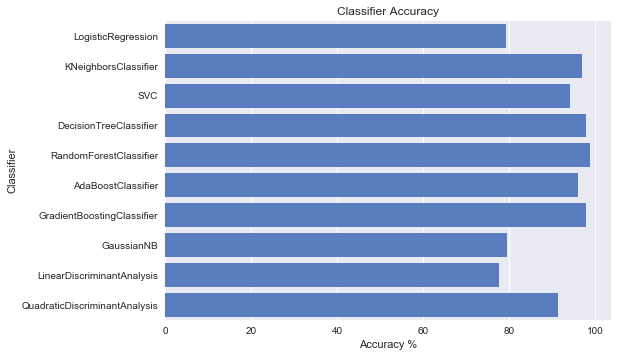

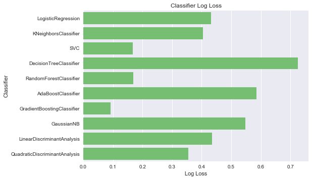

```python
sns.set_color_codes("muted")
sns.barplot(x='Accuracy', y='Classifier', data=log, color="b")

plt.xlabel('Accuracy %')
plt.title('Classifier Accuracy')
plt.show()

sns.set_color_codes("muted")
sns.barplot(x='Log Loss', y='Classifier', data=log, color="g")

plt.xlabel('Log Loss')
plt.title('Classifier Log Loss')
plt.show()
```

```python
from sklearn.metrics import precision_score, recall_score, confusion_matrix
for clf in classifiers:
    clf.fit(X_train, y_train)
    name = clf.__class__.__name__
    print("="*30)
    print(name)

    print('****Confusion Matrix****')
    con=confusion_matrix(y_test, clf.predict(X_test))
    print(con)
    print('Precision')
    Precision=precision_score(y_test, clf.predict(X_test))
    print(Precision)
    print('Recall')
    Recall=recall_score(y_test, clf.predict(X_test))
    print(Recall)
```

```
==============================
LogisticRegression
****Confusion Matrix****
[[2120  162]
 [ 464  254]]
Precision
0.610576923077
Recall
0.353760445682
==============================
KNeighborsClassifier
****Confusion Matrix****
[[2232   50]
 [  42  676]]
Precision
0.931129476584
Recall
0.941504178273
==============================
SVC
****Confusion Matrix****
[[2209   73]
 [ 101  617]]
Precision
0.894202898551
Recall
0.859331476323
==============================
DecisionTreeClassifier
****Confusion Matrix****
[[2242   40]
 [  23  695]]
Precision
0.945578231293
Recall
0.967966573816
==============================
RandomForestClassifier
****Confusion Matrix****
[[2280    2]
```

[output cut: 35 more lines]

```
[[2118  164]
 [ 510  208]]
Precision
0.559139784946
Recall
0.289693593315
==============================
QuadraticDiscriminantAnalysis
****Confusion Matrix****
[[2107  175]
 [  89  629]]
Precision
0.782338308458
Recall
0.876044568245
```

### Preprocessing of the dataset

The data that was obtained was clean itself without any abnormalities or missing values. Therefore, no such efforts for preprocessing of the dataset was required.

## Discussing the results of the project

[output not shown]

#### Common Traits of Good people leaving

• Experienced  
• Very low satisfaction levels  
• Spend more time at work

#### Possible Reasons for people leaving:

• Experienced people may not be finding any challenges in work. Hence they leave.  
• Work to Pay ratio may be high (because we find clear correlation only in low and medium salary ranges)  
In nutshell:  
 If employees are successful and overworked, they leave.  
 If employees are unhappy and overworked, they leave.  
 If employees are unhappy and underworked, they leave.  
 If employees have been at the company for more than 6.5 years, they are more likely to be happy, and fine to work long hours.

## How the solution could be improved

ROC (Receiver Operating Characteristic) can be plotted to see the relative performance of precision and recall of the classifier, as the decision threshold is varied. Thus, when we have different classifiers to choose from, we plot their performances as ROC, and evaluate them. From ROC curve we can also judge the optimum threshold and this way the results can even further be enhanced.  
Secondly, a machine learning curve can also be plotted which is useful for many purposes including comparing different algorithms, choosing model parameters during design, adjusting optimization to improve convergence, and determining the amount of data used for training.

#### References:

https://machinelearningmastery.com/metrics-evaluate-machine-learning-algorithms-python/  
https://www.cgi.com/sites/default/files/files_cz/brochures/hr_whitepaper.pdf  
Wikipedia